# 통계밥법론 Chap5 실습코드

202140191 엄태훈

2021-03-27(SAT)

# Chap5 Introductory Inference

152P ~ 173P () Chap5의 절반을 나눠서 진행했습니다.  
다음 과제에서 Chap5의 남은 절반을 실습할 계획입니다.

### 5.1.1 Test of a Hypothesis Concering the Mean of a Population Having Known Standard Deviation

`NTplot`을 이용하여 기각역, 신뢰구간 등 가설검정에 대한 다양한 시각화를 진행할 수 있다.  
- alpha.right: 우측의 유의수준을 설정한다.  
- alpha.left: 좌측의 유의수준을 설정한다.  
- alpha.left, alpha.right를 동시에 설정하면 좌측검정, 우측검정의 결과값을 동시에 보여준다.  
- distribution.name을 통해 분포의 형태를 지정할 수 있다.(normal, z,t,binomial)  
type = “confidence”로 지정하게 되면 신뢰구간의 하한 상한을 구할 수 있다.

```r
library(HH)
```

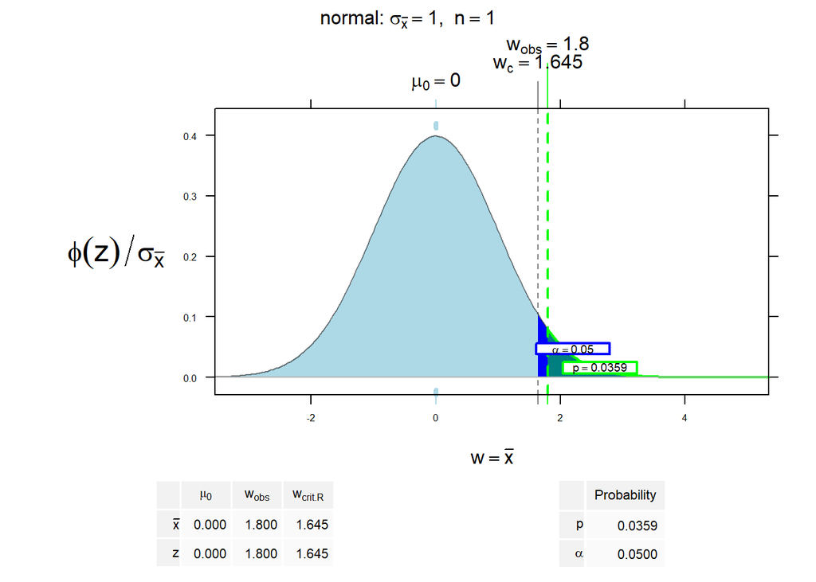

```r
NTplot(mean0=0,xbar=1.8,sd=1,alpha.right=0.05,alpha.left=0,shiny=FALSE,n=1,distribution.name="normal")
```

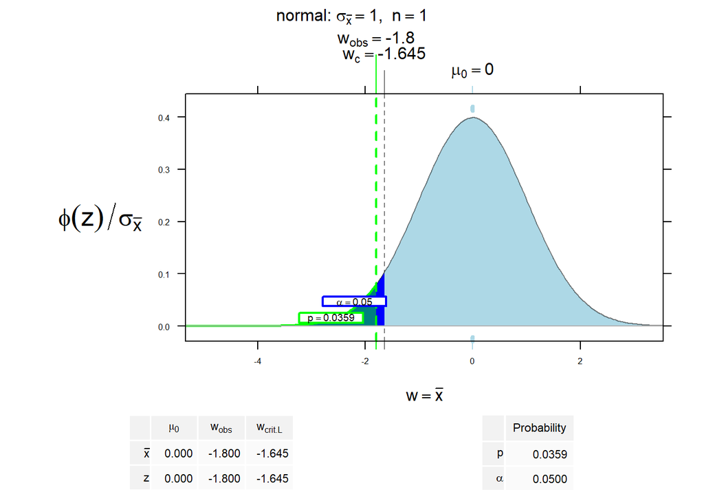

```r
NTplot(mean0=0,xbar=-1.8,sd=1,alpha.left=0.05,alpha.right=0,shiny=FALSE,n=1,distribution.name="normal")
```

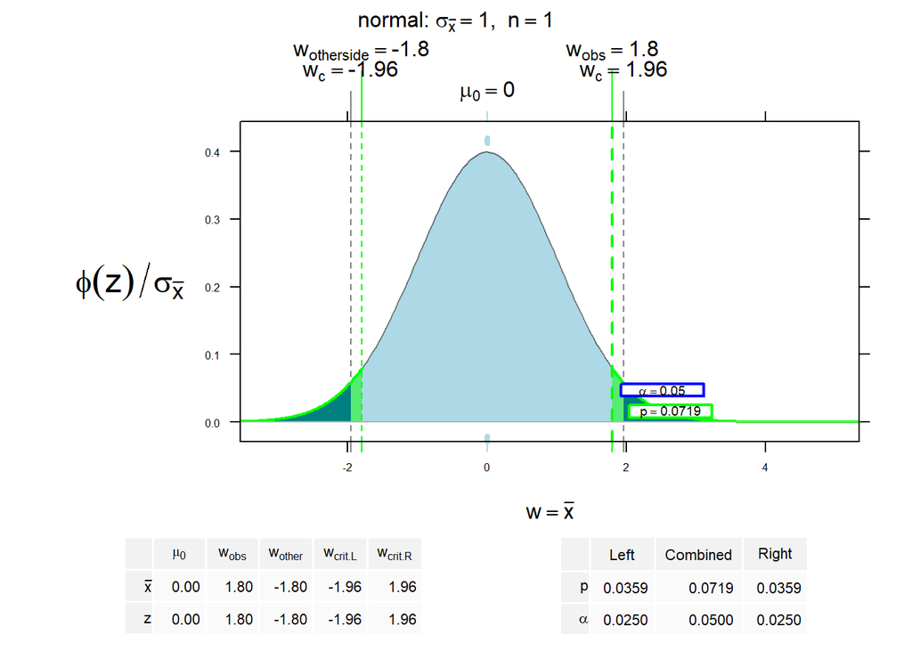

```r
NTplot(mean0=0,xbar=1.8,sd=1,alpha.left=0.025,alpha.right=0.025,shiny=FALSE,n=1,distribution.name="normal")
```

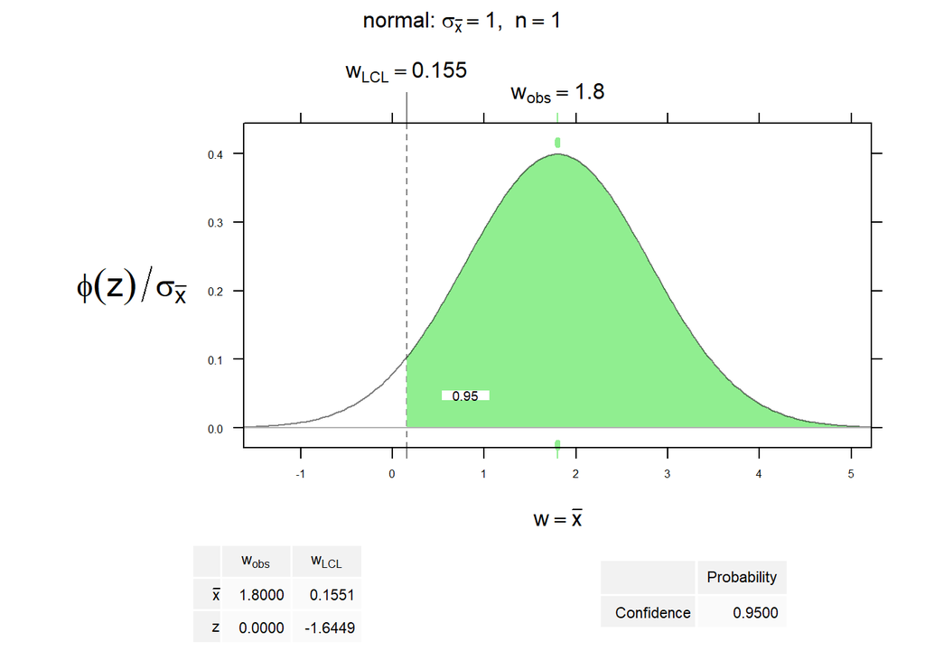

```r
NTplot(mean0=0,xbar=1.8,sd=1,type="confidence",alpha.left=0.05,alpha.right=0,shiny=FALSE,n=1,distribution.name="normal")
```

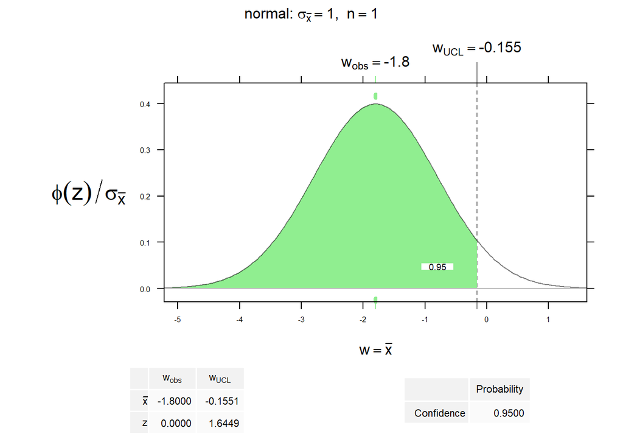

```r
NTplot(mean0=0,xbar=-1.8,sd=1,type="confidence",alpha.right=0.05,alpha.left=0,shiny=FALSE,n=1,distribution.name="normal")
```

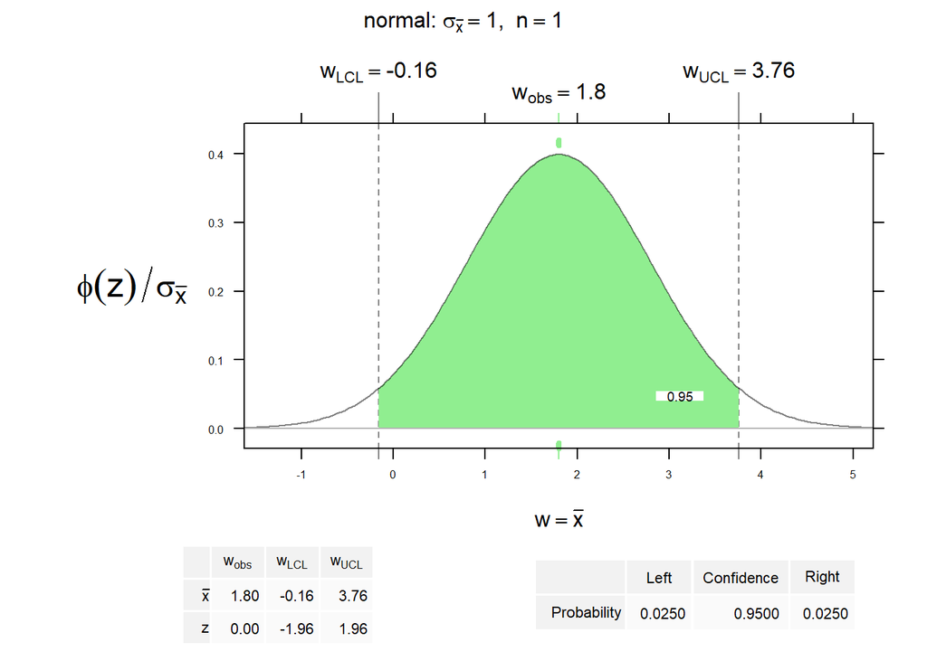

```r
NTplot(mean0=0,xbar=1.8,sd=1,type="confidence",alpha.left=0.025,alpha.right=0.025,shiny=FALSE,n=1,distribution.name="normal")
```

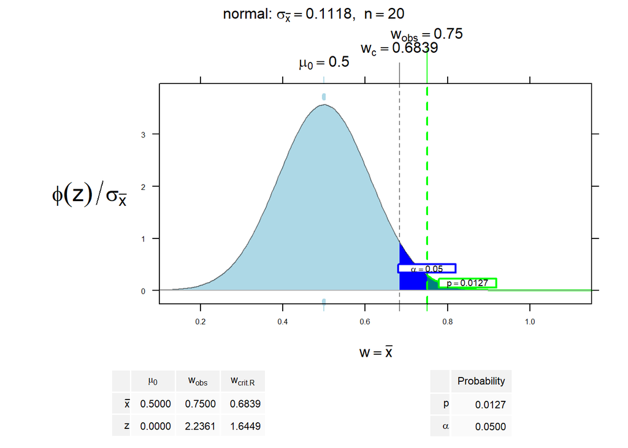

```r
library(HH)

NTplot(mean0=0.5,xbar=0.75,sd=0.5,alpha.right=0.05,alpha.left=0,shiny=FALSE,n=20,distribution.name="normal")
```

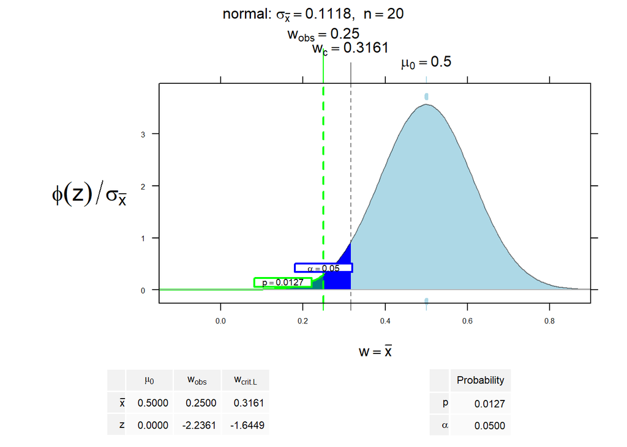

```r
NTplot(mean0=0.5,xbar=0.25,sd=0.5,alpha.left=0.05,alpha.right=0,shiny=FALSE,n=20,distribution.name="normal")
```

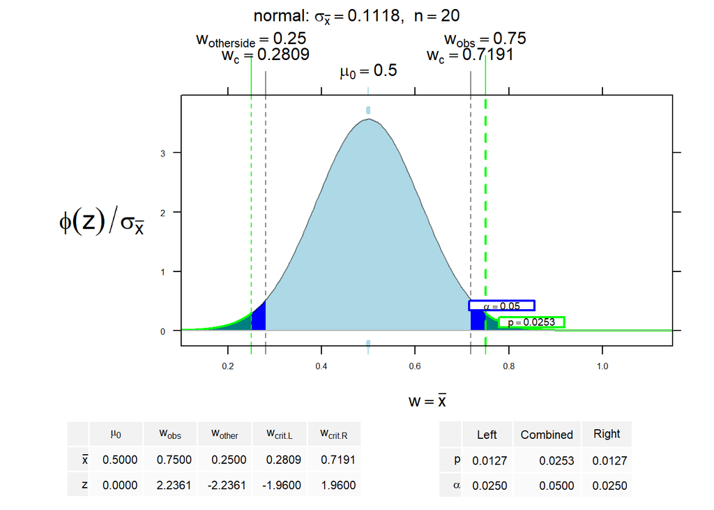

```r
NTplot(mean0=0.5,xbar=0.75,sd=0.5,alpha.left=0.025,alpha.right=0.025,shiny=FALSE,n=20,distribution.name="normal")
```

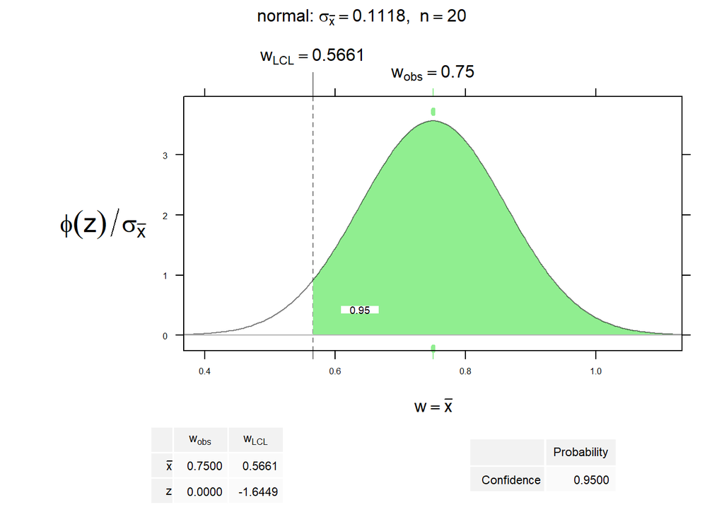

```r
NTplot(mean0=0.5,xbar=0.75,sd=0.5,type="confidence",alpha.left=0.05,alpha.right=0,shiny=FALSE,n=20,distribution.name="normal")
```

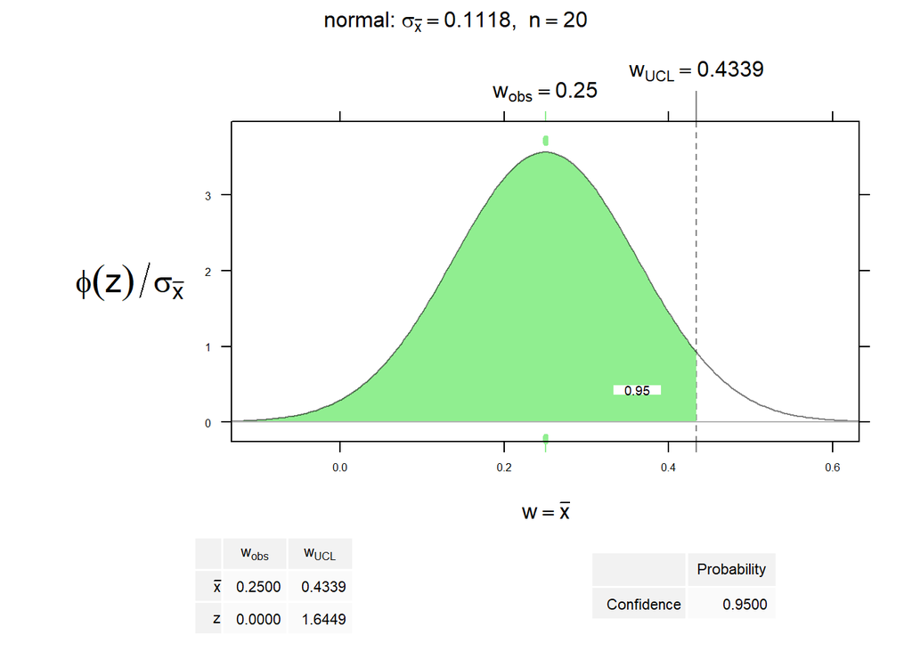

```r
NTplot(mean0=0.5,xbar=0.25,sd=0.5,type="confidence",alpha.right=0.05,alpha.left=0,shiny=FALSE,n=20,distribution.name="normal")
```

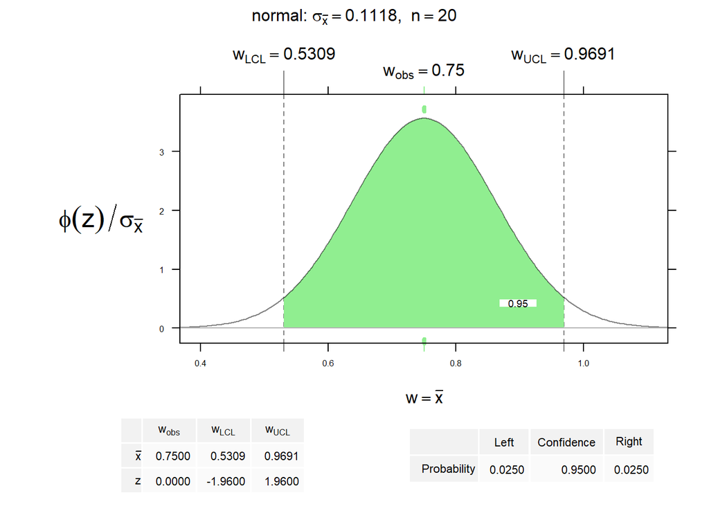

```r
NTplot(mean0=0.5,xbar=0.75,sd=0.5,type="confidence",alpha.left=0.025,alpha.right=0.025,shiny=FALSE,n=20,distribution.name="normal")
```

## 5.2.1 Example - Inference on a Population Mean U

R에 내장돼있는 stem 함수를 이용하게 되면 데이터에 대한 줄기-잎 그림을 그릴 수 있다.

```r
data(vocab)
stem(vocab$score,scale=2)
```

```
##
##   The decimal point is at the |
##
##    9 | 0
##   10 | 0000
##   11 | 0000000000000
##   12 | 0000000
##   13 | 000000000
##   14 | 000000000
##   15 | 0000
##   16 | 00000
##   17 | 0
##   18 |
##   19 | 0
```

## 5.3 Confidence Interval the Variance or Standard Deviation of a Normal Population

NTplot의 distribution.name = “t”로 지정함으로써 정규분포가 아닌 t분포에 대해서도 시각화를 진행할 수 있다. t분포를 지정했을 경우, df를 통해 자유도 또한 지정해줘야 한다.

```r
vocab.t <- t.test(vocab$score,mu=10)
sd(vocab$score)
```

```
## [1] 2.092631
```

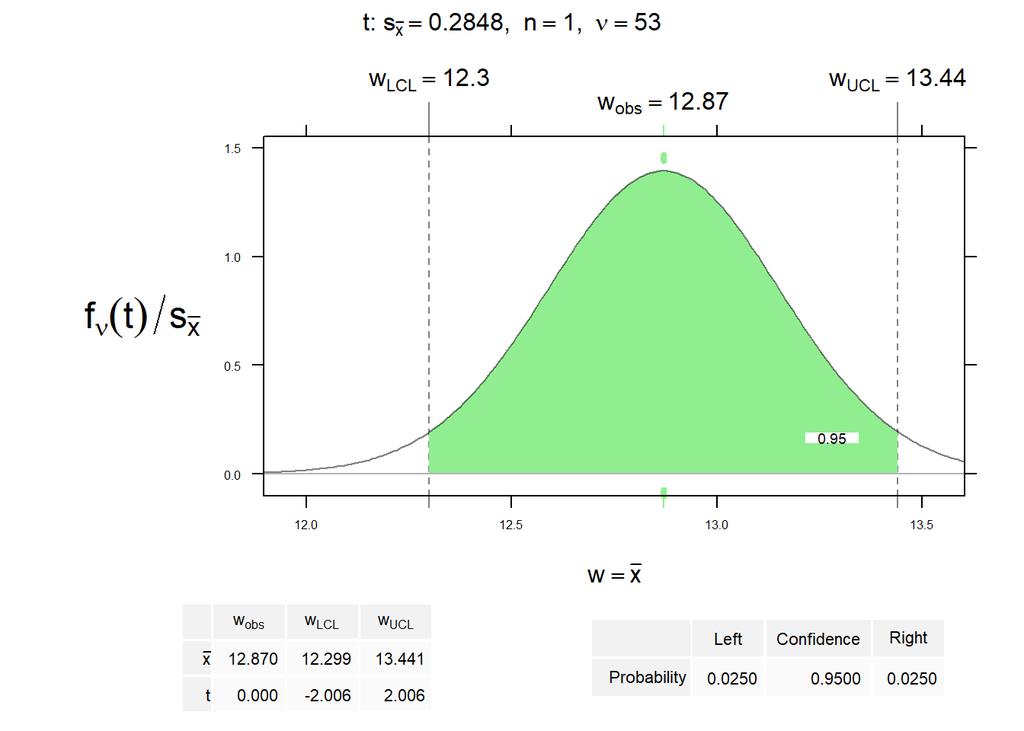

```r
NTplot(xbar=12.87,sd=0.2848,xlim=c(12.0,13.5),type="confidence",
       alpha.right=.025,alpha.left=0.025,distribution.name="t",n=1,df=53)
```

t.test의 결과를 한 객체에 저장하고 NTplot을 그릴 수 있다.  
이는 t.test의 결과를 시각적으로 도출해준다.

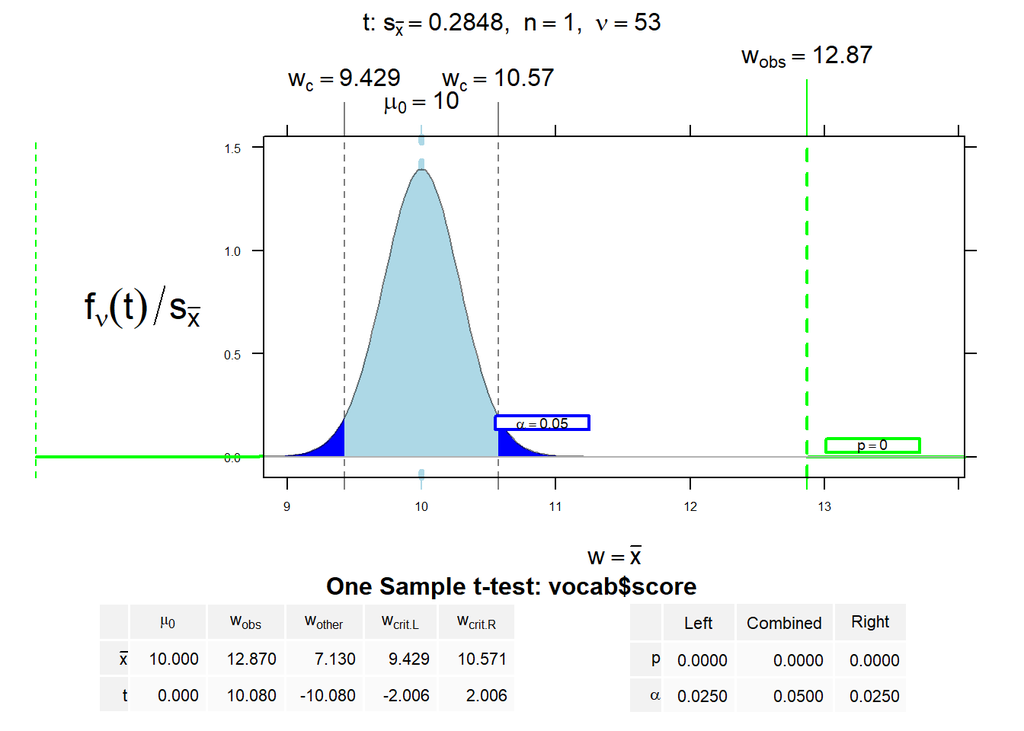

```r
NTplot(vocab.t)
```

## chisq-distribution을 기본 plot을 통해 그리기

dchisq를 통해 카이제곱분포의 확률밀도함수를 쉽게 풀 수 있다.

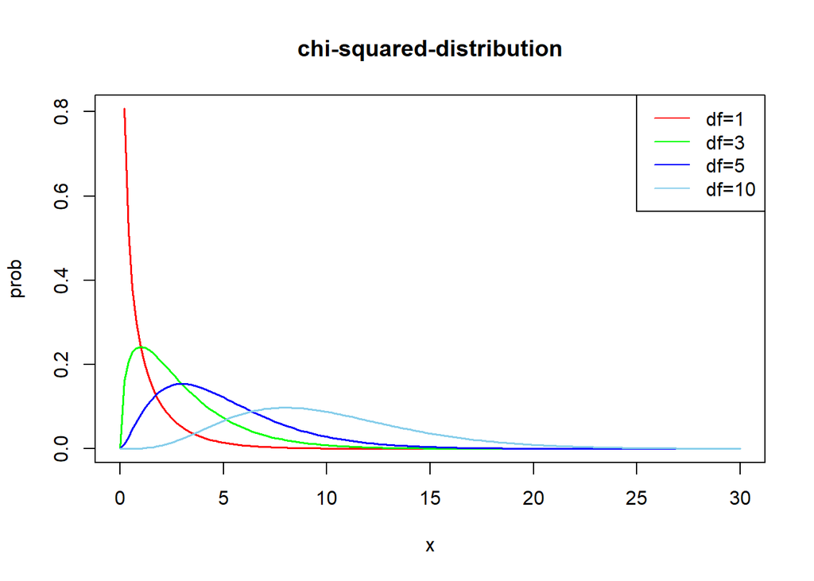

```r
x <- seq(0,30,by=0.2)
y1 <- dchisq(x,df=1)
y2 <- dchisq(x,df=3)
y3 <- dchisq(x,df=5)
y4 <- dchisq(x,df=10)

plot(x,y1,type="n",main="chi-squared-distribution",xlab='x',
     ylab='prob')
lines(x,y1,col="red",lwd=1.5)
lines(x,y2,col="green",lwd=1.5)
lines(x,y3,col="blue",lwd=1.5)
lines(x,y4,col="skyblue",lwd=1.5)
legend('topright',lwd=c(1,1,1,1),col=c("red",'green','blue','skyblue'),
       legend=c('df=1','df=3','df=5','df=10'))
```

자유도가 커질수록 종 모양에 가까워지는 것을 확인할 수 있다.

HH패키지는 chisq, f분포에 대한 시각화 함수 또한 제공한다.  
chisq.setup: 자유도에 해당하는 카이제곱 분포의 틀을 잡는다.  
chisq.curve: 자유도에 해당하는 카이제곱 분포를 그린다. - col을 통해 색깔을 지정할 수 있다. - xlim.in을 통해 x의 범위를 지정할 수 있다.  
- xlim.in의 qchisq.intermediate를 통해 유의 확률에 따라서 조절할 수도 있다.  
- ylim.in을 통해 y의 범위를 지정할 수 있다.

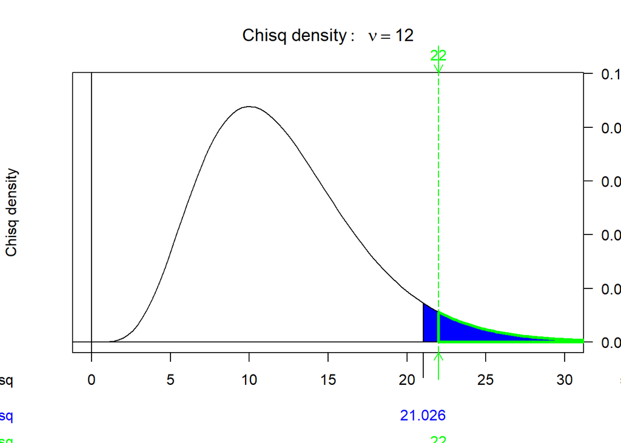

```r
chisq.setup(df=12,xlim.in=c(0,30))
chisq.curve(df=12, col='blue')
chisq.observed(22, df=12)
```

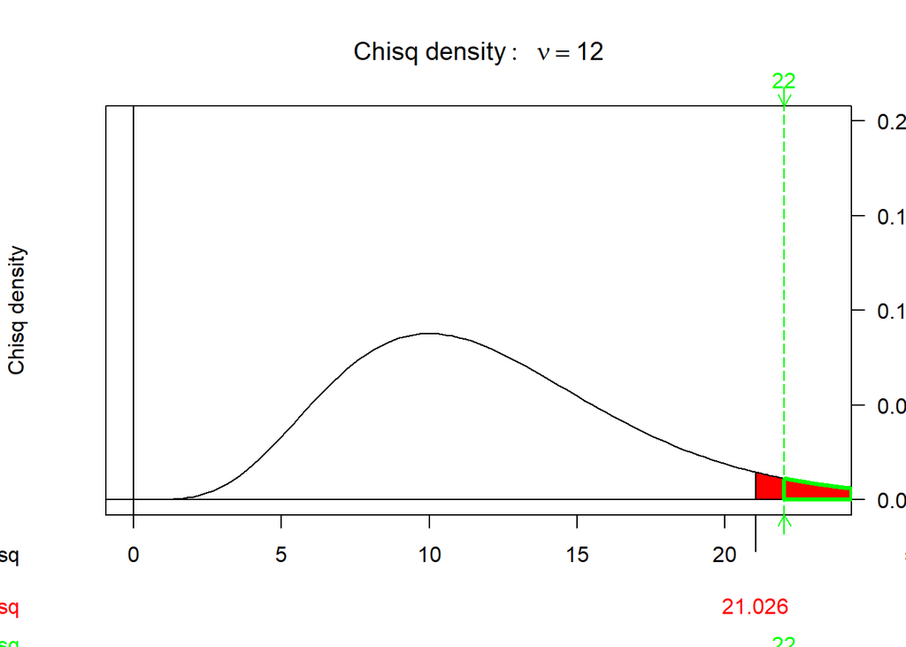

```r
chisq.setup(df=12,xlim.in=c(0,qchisq.intermediate(p=1-.025,df=12)),ylim.in=c(0,0.2))
chisq.curve(df=12, col='RED')
chisq.observed(22, df=12)
```

type=**“confidnce”**을 통해 신뢰구간을 추정할 수 있다.

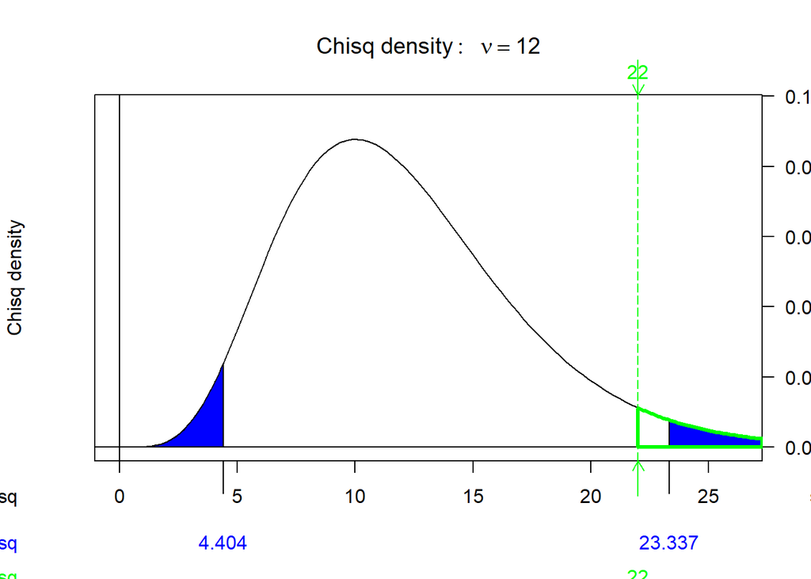

```r
chisq.setup(df=12)
chisq.curve(df=12,col='blue',alpha=c(.025,.025),type="confidence")
chisq.observed(22, df=12)
```

F분포는 chisq 분포와 달리 2개의 자유도를 입력해야 한다.  
F.setup: 자유도에 해당하는 F 분포의 틀을 잡는다.  
F.curve: 자유도에 해당하는 F 분포를 그린다. - col을 통해 색깔을 지정할 수 있다. - xlim.in을 통해 x의 범위를 지정할 수 있다.  
- ylim.in을 통해 y의 범위를 지정할 수 있다. - main.in을 통해 title을 설정할 수 있다.  
alpha: 설정한 유의수준에 대한 기각역을 보여준다. - 하나의 값을 입력하면 자동으로 우측 검정으로 실행된다.

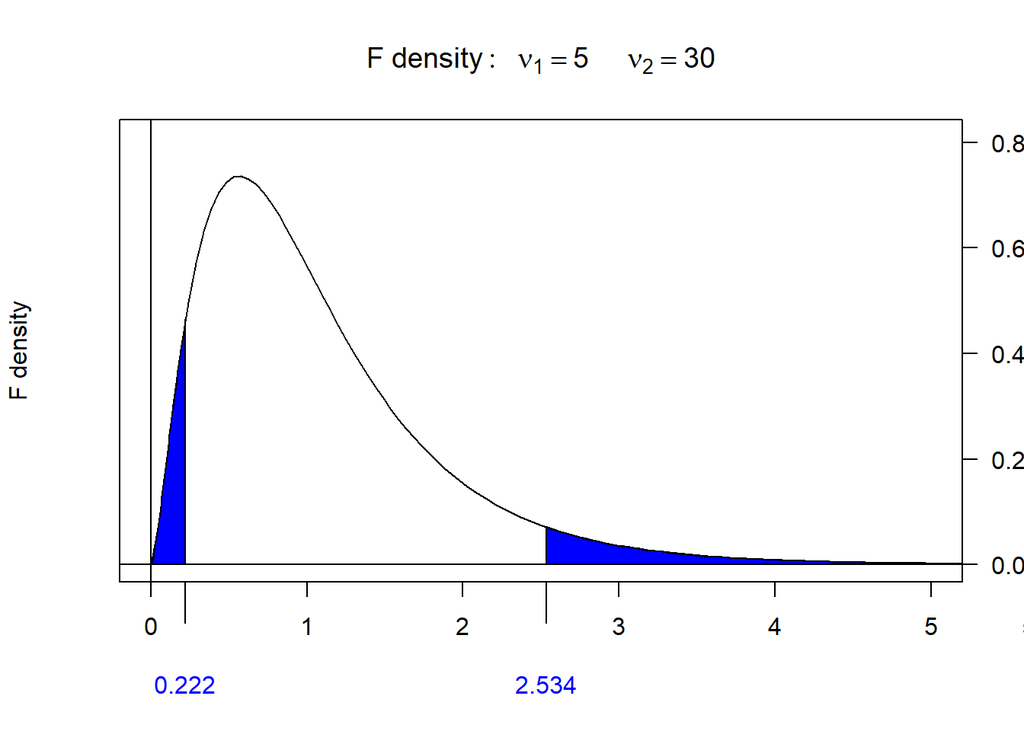

```r
F.setup(df1=5, df2=30)
F.curve(df1=5, df2=30, col='blue', alpha=c(.05, .05))
```

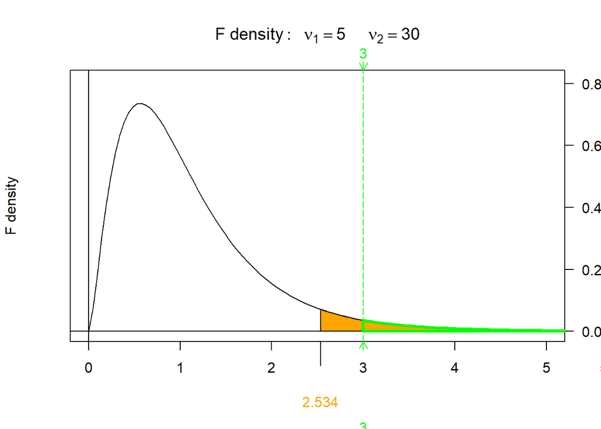

```r
F.setup(df1=5, df2=30,)
F.curve(df1=5, df2=30, col='Orange',xlim.in=c(0,5))
F.observed(3, df1=5, df2=30)
```

## 5.4.3 Tests Comparing Two Population Means When the Samples Are Independent

2 sample t에 대한 결과를 NTplot을 통해 시각적으로 도출할 수 있다.

```r
data(cereals)
table(cereals[,c("mfr","type")])
```

```
##    type
## mfr  C  H
##   A  0  1
##   G 22  0
##   K 23  0
##   N  5  1
##   P  9  0
##   Q  7  1
##   R  8  0
```

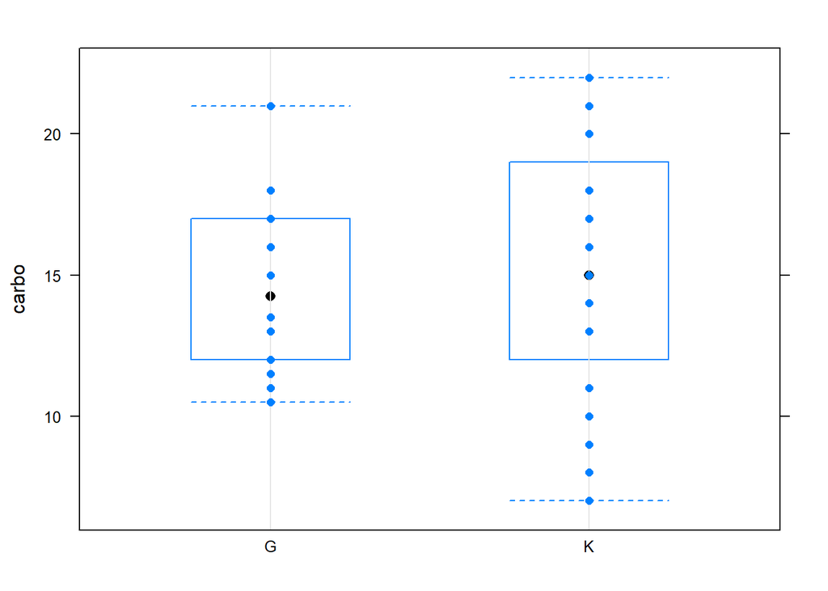

```r
C.KG <- cereals$type=="C" & cereals$mfr %in% c("K","G")
cerealsC <- cereals[C.KG,c("mfr","carbo")]
cerealsC$mfr <- factor(cerealsC$mfr)
bwplot(carbo ~ mfr,data=cerealsC)+
  dotplot(carbo ~ mfr,data=cerealsC)
```

```r
t.t <- t.test(carbo ~ mfr, data=cerealsC,
              var.equal=TRUE)
t.t
```

```
##
##  Two Sample t-test
##
## data:  carbo by mfr
## t = -0.34148, df = 43, p-value = 0.7344
## alternative hypothesis: true difference in means is not equal to 0
## 95 percent confidence interval:
##  -2.784151  1.977827
## sample estimates:
## mean in group G mean in group K
##        14.72727        15.13043
```

```r
mm <- tapply(cerealsC$carbo,cerealsC$mfr,mean)
vv <- tapply(cerealsC$carbo,cerealsC$mfr,var)
ll <- tapply(cerealsC$carbo,cerealsC$mfr,length)
s2p <- ((ll-1) %*% vv) / sum(ll-1)

tt <- -diff(mm) / (sqrt(s2p) * sqrt(sum(1/ll)))
tt
```

```
##            [,1]
## [1,] -0.3414773
```

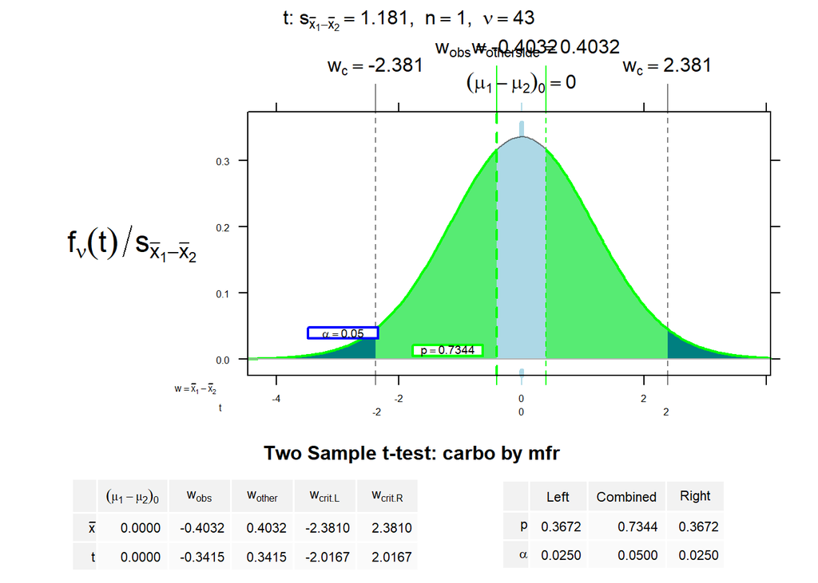

```r
NTplot(t.t,zaxis=TRUE,shiny=FALSE)
```

## 5.5.1 Example-t-test on Matched Pairs of Means

```r
library(lattice)
data(teachers)
str(teachers)
```

```
## 'data.frame':    32 obs. of  2 variables:
##  $ English: int  22 16 42 25 31 36 29 24 29 18 ...
##  $ Greek  : int  36 9 29 35 34 23 25 31 35 21 ...
```

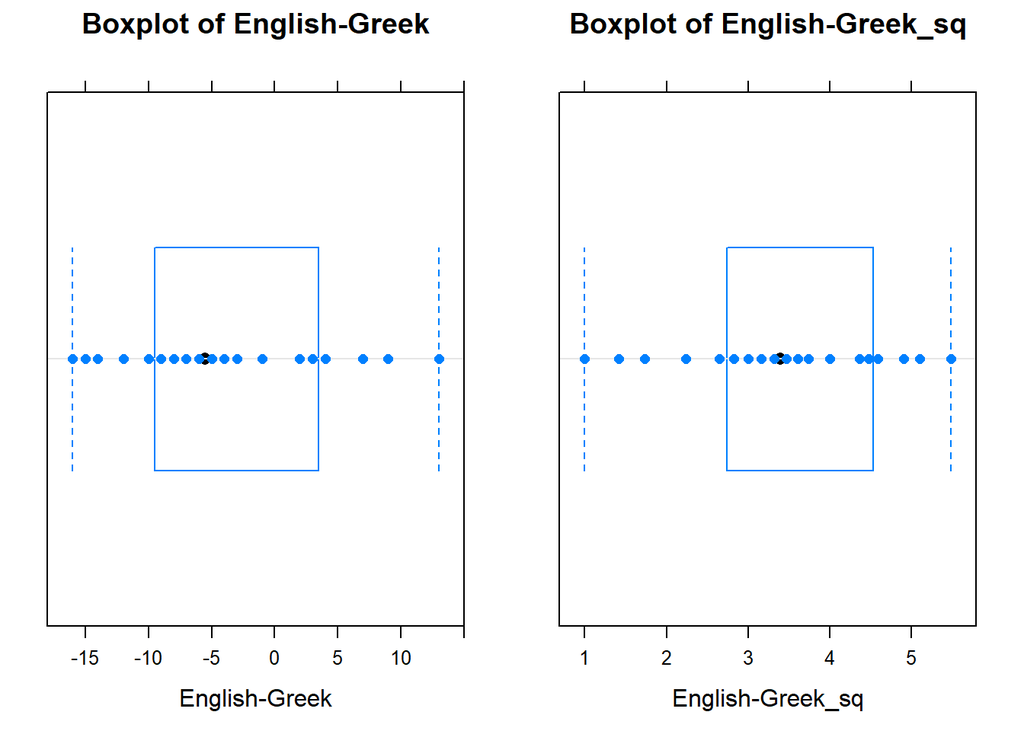

```r
teachers$English_Greek = teachers$English - teachers$Greek

teachers$English_Greek_sq = sqrt(teachers$English - teachers$Greek + 17)

a<-bwplot(teachers$English_Greek,xlab="English-Greek",main="Boxplot of English-Greek")+
  dotplot(teachers$English_Greek,xlab="English-Greek")
b<-bwplot(teachers$English_Greek_sq,xlab="English-Greek_sq",main="Boxplot of English-Greek_sq")+
  dotplot(teachers$English_Greek_sq,xlab="English_Greek_sq")

print(a,split=c(1,1,2,1),more=TRUE)
print(b,split=c(2,1,2,1),more=FALSE)
```

```r
stem(teachers$English_Greek)
```

```
##
##   The decimal point is 1 digit(s) to the right of the |
##
##   -1 | 65
##   -1 | 442000
##   -0 | 988887665
##   -0 | 4331
##    0 | 22344
##    0 | 7799
##    1 | 33
```

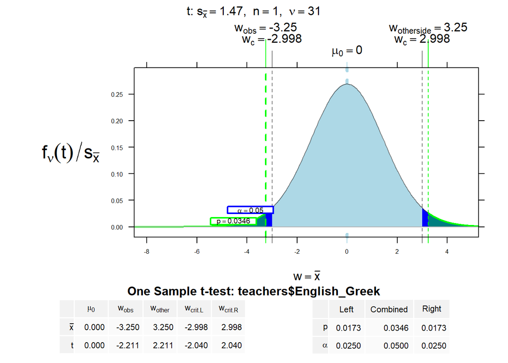

```r
Eng_Greek_ttest<-t.test(teachers$English_Greek)
NTplot(Eng_Greek_ttest)
```

```r
stem(sqrt(teachers$English_Greek+17),scale=.5)
```

```
##
##   The decimal point is at the |
##
##   1 | 0477
##   2 | 26668
##   3 | 00002335677
##   4 | 04456699
##   5 | 1155
```

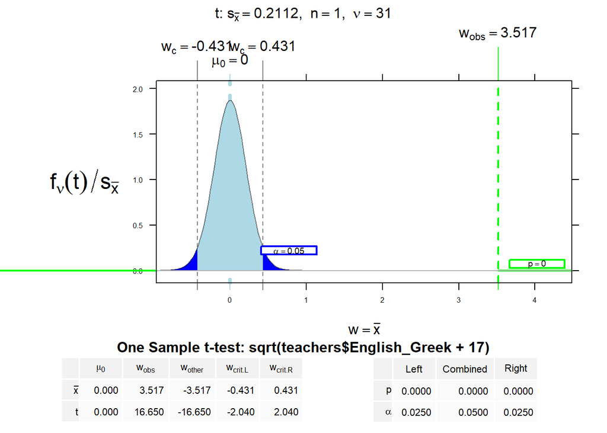

```r
Eng_Greek_ttest_sq<-t.test(sqrt(teachers$English_Greek+17),scale=.5)
NTplot(Eng_Greek_ttest_sq)
```

## 5.6.2 Sample Size for Hypothesis Testing

mean0와 mean1를 동시에 설정하면 귀무가설과 대립가설의 분포를 동시에 확인할 수 있다.

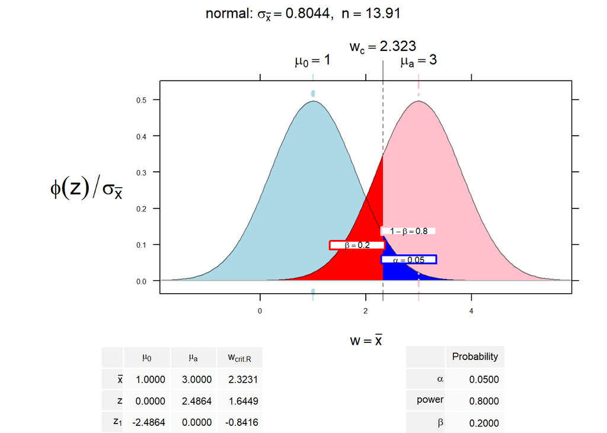

```r
NTplot(mean0=1,mean1=3,n=13.91,sd=3,distribution.name="normal")
```